Map units (AREASYMBOL): CA630  
report version 3.3.4  
2018-02-21

This report is designed to provide statistical summaries of the environmental properties for one or more map units. Summaries are based on raster data extracted from [fixed-density sampling of map unit polygons](http://ncss-tech.github.io/AQP/sharpshootR/sample-vs-population.html). [Percentiles](https://ncss-tech.github.io/soil-range-in-characteristics/why-percentiles.html) are used as robust metrics of distribution central tendency and spread. Please see the document titled *R-Based Map Unit Summary Report Introduction and Description* for background and setup.

### Map Unit Polygon Data Source

| MU.Polygons | File.or.Feature |
| --- | --- |
| L:/NRCS/MLRAShared/CA630/FG_CA630_OFFICIAL.gdb | ca630_b |

### Raster Data Sources

| Variable | File | inMemory | ContainsMU | Moran.I |
| --- | --- | --- | --- | --- |
| Mean Annual Air Temperature (degrees C) | E:/gis_data/prism/final_MAAT_800m.tif | TRUE | TRUE | 0 |
| Mean Annual Precipitation (mm) | E:/gis_data/prism/final_MAP_mm_800m.tif | TRUE | TRUE | 0 |
| Effective Precipitation (mm) | E:/gis_data/prism/effective_precipitation_800m.tif | TRUE | TRUE | 0 |
| Frost-Free Days | E:/gis_data/prism/ffd_50_pct_800m.tif | TRUE | TRUE | 0 |
| Growing Degree Days (degrees C) | E:/gis_data/prism/gdd_mean_800m.tif | TRUE | TRUE | 0 |
| Elevation (m) | E:/gis_data/region-2-mu-analysis/elev_30.tif | FALSE | TRUE | 0 |
| Slope Gradient (%) | E:/gis_data/region-2-mu-analysis/slope_30.tif | FALSE | TRUE | 0 |
| Annual Beam Radiance (MJ/sq.m) | E:/gis_data/ca630/beam_rad_sum_mj_30m.tif | TRUE | TRUE | 0 |
| (Estimated) MAST (degrees C) | E:/gis_data/ca630/mast-model.tif | TRUE | TRUE | 0 |
| NLCD Impervious Surface (%) | E:/gis_data/region-2-mu-analysis/nlcd_impervious_2011_cropped.tif | FALSE | TRUE | 0 |
| SAGA TWI | E:/gis_data/ca630/saga_twi_10.tif | TRUE | TRUE | 0 |
| Geomorphon Landforms | E:/gis_data/region-2-mu-analysis/forms10_region2.tif | FALSE | TRUE | 0 |
| Curvature Classes | E:/gis_data/region-2-mu-analysis/curvature_classes_10_class_region2.tif | FALSE | TRUE | 0 |
| NLCD 2011 | E:/gis_data/region-2-mu-analysis/nlcd_2011_cropped.tif | FALSE | TRUE | 0 |
| Slope Aspect (degrees) | E:/gis_data/region-2-mu-analysis/aspect_30.tif | FALSE | TRUE | 0 |

### Area Summaries

Target sampling density: **0.01 points/ac.** defined in `config.R`. Consider increasing if there are unsampled polygons or if the number of samples is less than *about 200*. Note that the mean sampling density (per polygon) will always be slightly lower than the target sampling density, depending on polygon shape.

Map Unit Acreage by Polygon

| AREASYMBOL | Min | Q5 | Q25 | Median | Q75 | Q95 | Max | Total Area | Samples | Polygons | Polygons Not Sampled | Mean Sample Dens. |
| --- | --- | --- | --- | --- | --- | --- | --- | --- | --- | --- | --- | --- |
| CA630 | 826190 | 826190 | 826190 | 826190 | 826190 | 826190 | 826190 | 826190 | 8255 | 1 | 0 | 0.01 |

### Modified Box and Whisker Plots

Whiskers extend from the 5th to 95th [percentiles](https://en.wikipedia.org/wiki/Percentile), the body represents the 25th through 75th percentiles, and the dot is the 50th percentile. Box width is proportional to the number of samples per map unit (e.g. total map unit area). Notches (if enabled) represent an approximate confidence interval around the median, adjusted for spatial autocorrelation. Overlapping notches suggest that median values are not significantly different. This feature can be enabled by setting `correct.sample.size=TRUE` in `config.R`.

**Suggested usage:**

- Gauge overlap between map units in terms of boxes (25th-75th percentiles) and whiskers (5th-95th percentiles).
- Non-overlapping boxes are a strong indication that the central tendencies (of select raster data) differ.
- Distribution shape is difficult to infer from box and whisker plots, remember to cross-reference with density plots below.

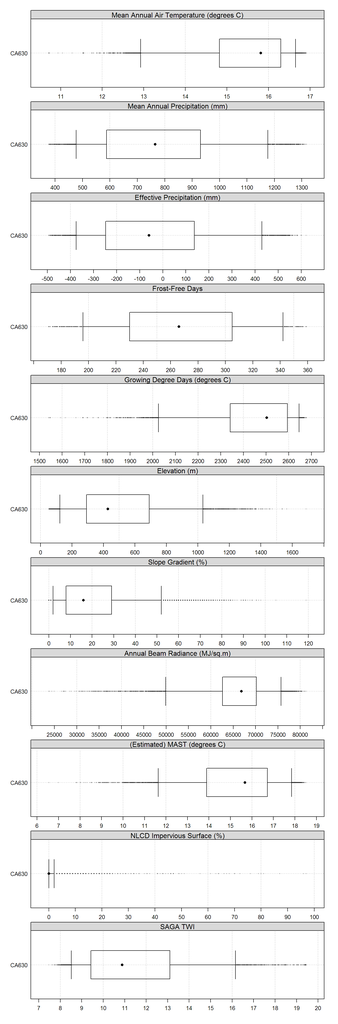

### Density Plots

These plots are a smooth alternative ([density estimation](https://en.wikipedia.org/wiki/Density_estimation)) to the classic "binned" ([histogram](https://en.wikipedia.org/wiki/Histogram)) approach to visualizing distributions. Peaks correspond to values that are most frequent within a data set. Each data set (ID / variable) are rescaled to {0,1} so that the y-axis can be interpreted as the "relative proportion of samples".

**Suggested usage:**

- Density plots depict a more detailed summary of distribution shape.
- When making comparisons, be sure to look for:
- multiple peaks
- narrow peaks vs. wide "mounds"
- short vs. long "tails"

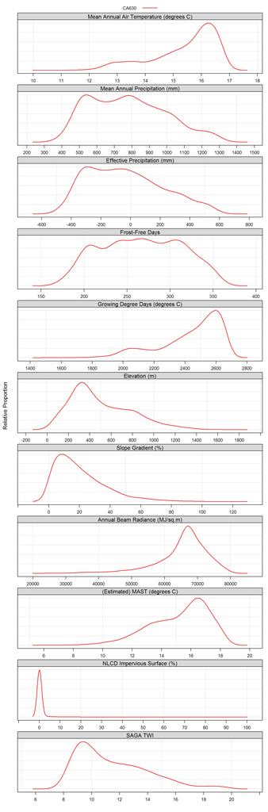

### Tabular Summaries

Table of select [percentiles](https://en.wikipedia.org/wiki/Percentile), by variable. In these tables, headings like "Q5" can be interpreted as the the "5th percentile"; 5% of the data are less than this value. The 50th percentile ("Q50") is the median.

Median Values

| AREASYMBOL | Mean Annual Air Temperature (degrees C) | Mean Annual Precipitation (mm) | Effective Precipitation (mm) | Frost-Free Days | Growing Degree Days (degrees C) | Elevation (m) | Slope Gradient (%) | Annual Beam Radiance (MJ/sq.m) | (Estimated) MAST (degrees C) | NLCD Impervious Surface (%) | SAGA TWI |
| --- | --- | --- | --- | --- | --- | --- | --- | --- | --- | --- | --- |
| CA630 | 15.81 | 765 | -59.8 | 266 | 2503 | 428 | 16 | 66825.45 | 15.68 | 0 | 10.88 |

Mean Annual Air Temperature (degrees C)

| AREASYMBOL | Q0 | Q1 | Q5 | Q10 | Q25 | Q50 | Q75 | Q90 | Q95 | Q99 | Q100 |
| --- | --- | --- | --- | --- | --- | --- | --- | --- | --- | --- | --- |
| CA630 | 10.71 | 12.39 | 12.92 | 13.48 | 14.82 | 15.81 | 16.3 | 16.57 | 16.65 | 16.77 | 16.91 |

Mean Annual Precipitation (mm)

| AREASYMBOL | Q0 | Q1 | Q5 | Q10 | Q25 | Q50 | Q75 | Q90 | Q95 | Q99 | Q100 |
| --- | --- | --- | --- | --- | --- | --- | --- | --- | --- | --- | --- |
| CA630 | 377 | 416 | 477 | 509 | 588 | 765 | 930 | 1070 | 1176 | 1272 | 1316 |

Effective Precipitation (mm)

| AREASYMBOL | Q0 | Q1 | Q5 | Q10 | Q25 | Q50 | Q75 | Q90 | Q95 | Q99 | Q100 |
| --- | --- | --- | --- | --- | --- | --- | --- | --- | --- | --- | --- |
| CA630 | -493.57 | -447.18 | -374.72 | -340.54 | -247.51 | -59.8 | 136.7 | 334.03 | 429.76 | 531.95 | 621.28 |

Frost-Free Days

| AREASYMBOL | Q0 | Q1 | Q5 | Q10 | Q25 | Q50 | Q75 | Q90 | Q95 | Q99 | Q100 |
| --- | --- | --- | --- | --- | --- | --- | --- | --- | --- | --- | --- |
| CA630 | 171 | 179 | 196 | 203 | 230 | 266 | 305 | 329 | 342 | 352 | 359 |

Growing Degree Days (degrees C)

| AREASYMBOL | Q0 | Q1 | Q5 | Q10 | Q25 | Q50 | Q75 | Q90 | Q95 | Q99 | Q100 |
| --- | --- | --- | --- | --- | --- | --- | --- | --- | --- | --- | --- |
| CA630 | 1541 | 1892 | 2025 | 2107 | 2342 | 2503 | 2594 | 2636 | 2646 | 2659 | 2677 |

Elevation (m)

| AREASYMBOL | Q0 | Q1 | Q5 | Q10 | Q25 | Q50 | Q75 | Q90 | Q95 | Q99 | Q100 |
| --- | --- | --- | --- | --- | --- | --- | --- | --- | --- | --- | --- |
| CA630 | 53 | 70 | 124 | 185 | 293 | 428 | 691.5 | 898 | 1032 | 1277 | 1688 |

Slope Gradient (%)

| AREASYMBOL | Q0 | Q1 | Q5 | Q10 | Q25 | Q50 | Q75 | Q90 | Q95 | Q99 | Q100 |
| --- | --- | --- | --- | --- | --- | --- | --- | --- | --- | --- | --- |
| CA630 | 0 | 0 | 2 | 3 | 8 | 16 | 29 | 42 | 52 | 73 | 119 |

Annual Beam Radiance (MJ/sq.m)

| AREASYMBOL | Q0 | Q1 | Q5 | Q10 | Q25 | Q50 | Q75 | Q90 | Q95 | Q99 | Q100 |
| --- | --- | --- | --- | --- | --- | --- | --- | --- | --- | --- | --- |
| CA630 | 23747.61 | 36956.59 | 49895.46 | 55465.37 | 62592.15 | 66825.45 | 70209.64 | 73795.78 | 75690.95 | 78418.05 | 81329.98 |

(Estimated) MAST (degrees C)

| AREASYMBOL | Q0 | Q1 | Q5 | Q10 | Q25 | Q50 | Q75 | Q90 | Q95 | Q99 | Q100 |
| --- | --- | --- | --- | --- | --- | --- | --- | --- | --- | --- | --- |
| CA630 | 6.54 | 10.02 | 11.64 | 12.47 | 13.89 | 15.68 | 16.72 | 17.46 | 17.84 | 18.2 | 18.53 |

NLCD Impervious Surface (%)

| AREASYMBOL | Q0 | Q1 | Q5 | Q10 | Q25 | Q50 | Q75 | Q90 | Q95 | Q99 | Q100 |
| --- | --- | --- | --- | --- | --- | --- | --- | --- | --- | --- | --- |
| CA630 | 0 | 0 | 0 | 0 | 0 | 0 | 0 | 0 | 2 | 20 | 97 |

SAGA TWI

| AREASYMBOL | Q0 | Q1 | Q5 | Q10 | Q25 | Q50 | Q75 | Q90 | Q95 | Q99 | Q100 |
| --- | --- | --- | --- | --- | --- | --- | --- | --- | --- | --- | --- |
| CA630 | 7.47 | 8.17 | 8.52 | 8.79 | 9.43 | 10.88 | 13.11 | 15.05 | 16.16 | 19.05 | 19.45 |

### Slope Aspect

A graphical summary of slope aspect values using density and percentile estimation methods adapted to circular data. Spread and central tendency are depicted with a combination of (circular) kernel density estimate (dashed blue lines) and arrows. The 50th percentile value is shown with a red arrow and the 10th and 90th percentile values are shown with gray arrows. Arrow length is proportional to the strength of directionality. Use the figures and table below to determine "clockwise" / "counter clockwise" values for NASIS component records.

**Suggested usage:**

- Check circular density estimates for peaks: this suggests directionality.
- These summaries are meaningless when slope values are less than approximately 3%.
- These summaries are (mostly) meaningless when arrow lengths are short; e.g. low directionality.
- There is no general relationship between 10th/90th percentiles and "clockwise" vs. "counterclockwise"

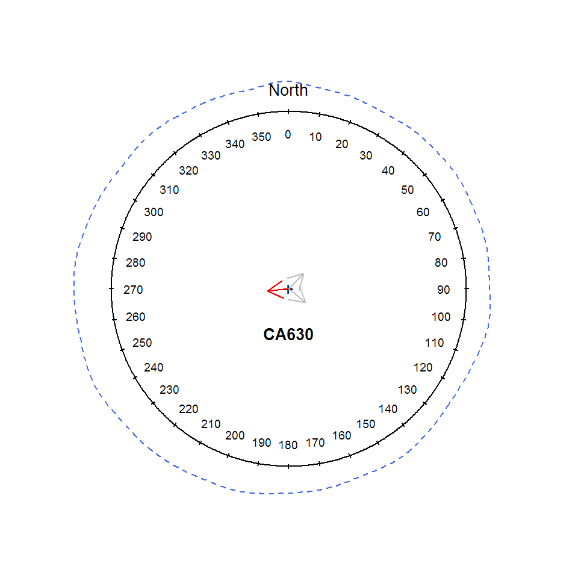

| AREASYMBOL | 10% | 50% | 90% |
| --- | --- | --- | --- |
| CA630 | 43 | 264 | 130 |

### Slope Shape (Curvature) Summary

Curvature classes were generated using a 5x5 moving window and a regional 30m or 10m integer DEM. The precision may be limited, so use with caution. See instructions for using your own (higher resolution) curvature classification raster. The conventions used here are "C" = concave, "L" = linear, and "V" = convex; "down slope" / "across slope". Window size has a significant impact on reported curvature classes; larger windows = more generalization. Curvature class and colors are aligned with an idealized *shedding* → *accumulating* hydrologic gradient.

**Suggested usage:**

Use the graphical summary to identify patterns, then consult the tabular representation for specifics. *

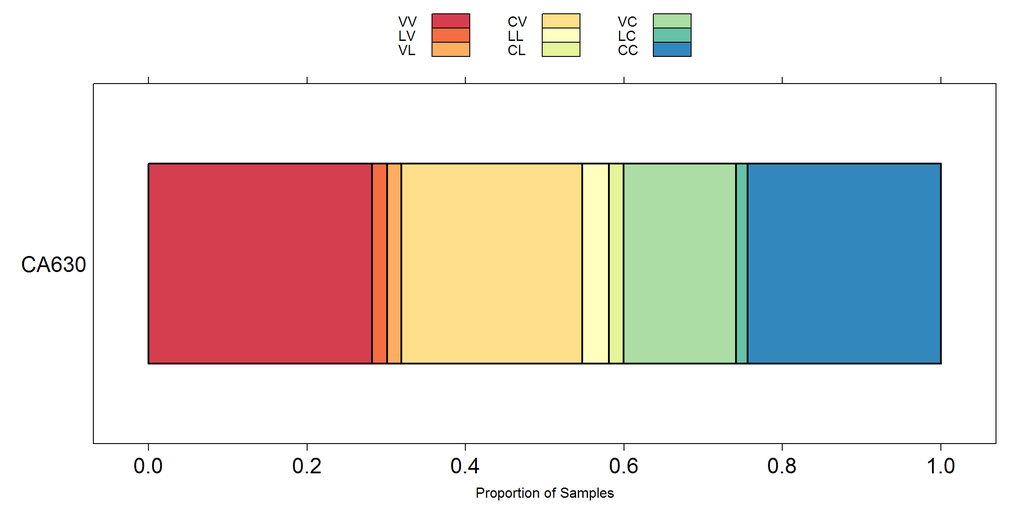

|  | VV | LV | VL | CV | LL | CL | VC | LC | CC |
| --- | --- | --- | --- | --- | --- | --- | --- | --- | --- |
| CA630 | 0.28 | 0.02 | 0.02 | 0.23 | 0.03 | 0.02 | 0.14 | 0.01 | 0.24 |

|  | mapunit composition "signature" (most frequent classes that sum to 75% or more) |
| --- | --- |
| CA630 | VV/CC |

### Geomorphon Landform Classification

Proportion of samples within each map unit that correspond to 1 of 10 possible landform positions, as generated via [geomorphon](https://grass.osgeo.org/grass70/manuals/addons/r.geomorphon.html) algorithm. Landform classification by [this method](http://dx.doi.org/10.1016/j.geomorph.2012.11.005) is scale-invariant and is therefore not affected by computational window size selection. Landform class labels and colors are aligned with an idealized *shedding* → *accumulating* hydrologic gradient. "Flat" is based on a 3% slope threshold.Map units are organized (in the figure) according to the similarity, computed from proportions of each landform position. The [dendrogram](http://ncss-tech.github.io/stats_for_soil_survey/chapter_5.html) on the right side of the figure describes relative similarity. "Lower branch height" (e.g. closer to the right-hand side of the figure) denotes more similar landform positions.

**Suggested usage:**

Use the graphical summary to identify patterns, then consult the tabular representation for specifics.

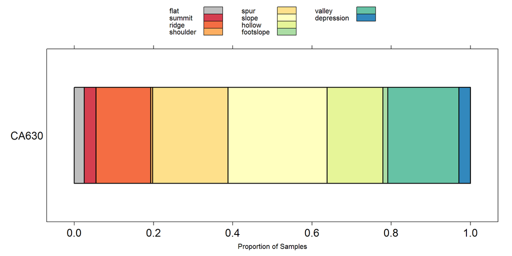

|  | flat | summit | ridge | shoulder | spur | slope | hollow | footslope | valley | depression |
| --- | --- | --- | --- | --- | --- | --- | --- | --- | --- | --- |
| CA630 | 0.03 | 0.03 | 0.14 | 0.01 | 0.19 | 0.25 | 0.14 | 0.01 | 0.18 | 0.03 |

|  | mapunit composition "signature" (most frequent classes that sum to 75% or more) |
| --- | --- |
| CA630 | slope/spur/valley |

### National Land Cover Dataset (NLCD)

These values are from the [2011 NLCD](https://www.mrlc.gov/nlcd2011.php) (30m) database.

**Suggested usage:**

Use the graphical summary to identify patterns, then consult the tabular representation for specifics.

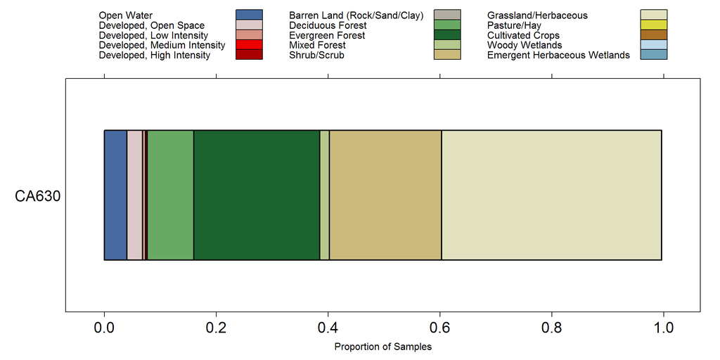

|  | Open Water | Developed, Open Space | Developed, Low Intensity | Developed, Medium Intensity | Deciduous Forest | Evergreen Forest | Mixed Forest | Shrub/Scrub | Grassland/Herbaceous |
| --- | --- | --- | --- | --- | --- | --- | --- | --- | --- |
| CA630 | 0.04 | 0.03 | 0.01 | 0 | 0.08 | 0.23 | 0.02 | 0.2 | 0.39 |

|  | mapunit composition "signature" (most frequent classes that sum to 75% or more) |
| --- | --- |
| CA630 | Grassland/Herbaceous/Evergreen Forest |

### Multivariate Summary

This plot displays the similarity of the map units across the set of environmental variables used in this report. The contours contain 75% (dotted line), 50% (dashed line), and 25% (solid line) of the points in an optimal [2D projection](https://en.wikipedia.org/wiki/Multidimensional_scaling#Non-metric_multidimensional_scaling) of multivariate data space. Data from map units with more than 1,000 samples are (sub-sampled via [cLHS](https://en.wikipedia.org/wiki/Latin_hypercube_sampling)). Map units with very low variation in environmental variables can result in tightly clustered points in the 2D projection. It is not possible to generate a multivariate summary when any sampled variable (e.g. slope) has a near-zero variance. See [this chapter](http://ncss-tech.github.io/stats_for_soil_survey/chapter_5.html), from the new *Statistics for Soil Scientists* NEDS course, for an soils-specific introduction to these concepts.

**Suggested usage:**

- The relative position of points and contours are meaningful; absolute position will vary each time the report is run.
- Colors match those used in the density plots above. Be sure to cross-reference this figure with density plots.
- Look for "diffuse" vs. "concentrated" clusters: these suggest relatively broadly vs. narrowly defined map unit concepts.
- Multiple, disconnected contours (per map unit) could indicate errors or small map unit separated by large distances. Check for multiple peaks in the associated density plots.
- Nesting of clusters (e.g. smaller cluster contained by larger cluster) suggests superset/subset relationships.
- Overlap is proportional to similarity.

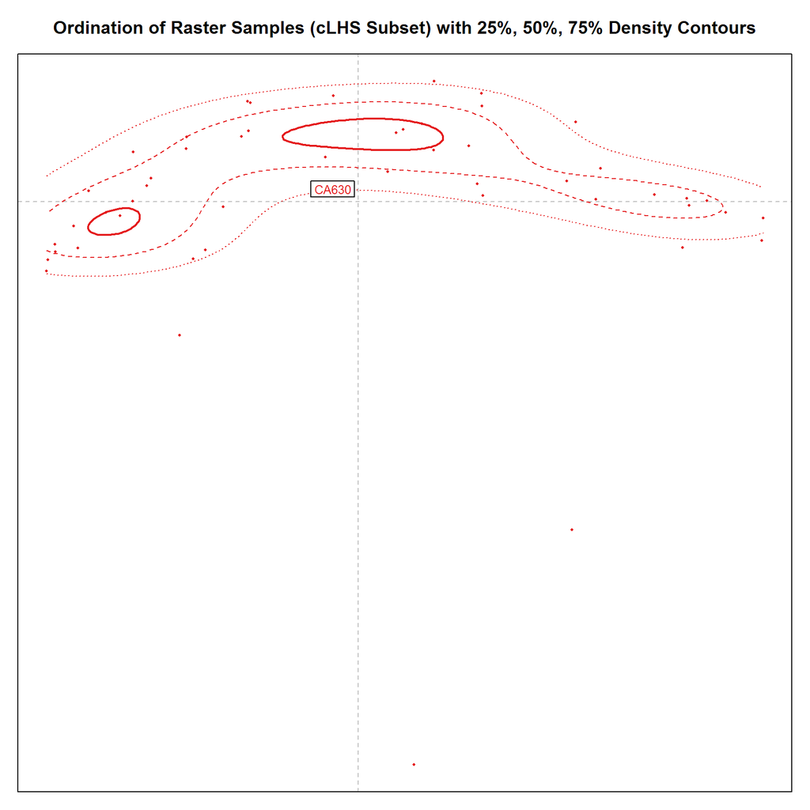

### Raster Data Correlation

The following figure highlights shared information among raster data sources based on [Spearman's Ranked Correlation coefficient](https://en.wikipedia.org/wiki/Spearman%27s_rank_correlation_coefficient). Branch height is associated with the degree of shared information between raster data.

**Suggested usage:**

- Look for clustered sets of raster data: typically PRISM-derived and elevation data are closely correlated.
- Highly correlated raster data sources reduce the reliability of the "raster data importance" figure.

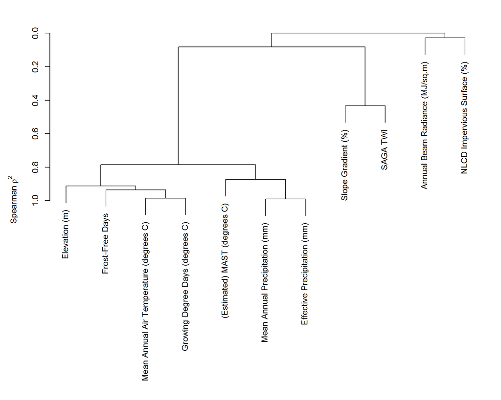

### Raster Data Importance

The following figure ranks raster data sources in terms of how accurately each can be used to discriminate between map unit concepts.

**Suggested usage:**

- Map unit concepts are more consistently predicted (by supervised classification) using those raster data sources with relatively larger "Mean Decrease in Accuracy" values.
- Highly correlated raster data sources will "compete" for positions in this figure. For example, if *elevation* and *mean annual air temperature* are highly correlated, then their respective "importance" values are interchangeable.

```
## [1] "This plot requires two or more map units."
```

## Polygon Summaries

A shapefile is generated each time a report is run ("polygons-with-stats-XXX" where "XXX" is the set of map units symbols listed in `config.R`) that contains several useful summaries, computed by polygon. Polygons are uniquely identified by the `pID` column. Median raster values are given, with data source names abbreviated to conform to the limitations of DBF files:

| pID | MUSYM | EstmtMASTC | AnnlBmRdMJ | EffctvPrcp | Elevationm | FrostFrDys | GrwngDgrDC | MnAnnlArTC | MnAnnlPrcp | SlopeGrdnt |
| --- | --- | --- | --- | --- | --- | --- | --- | --- | --- | --- |
| 1 | 7011 | 17.75 | 67118.27 | -413.72 | 139.0 | 319 | 2656 | 16.58 | 443 | 5 |
| 2 | 7011 | 16.66 | 67126.19 | -231.08 | 298.0 | 293 | 2583 | 16.20 | 612 | 2 |
| 3 | 7089 | 15.46 | 56270.39 | -84.02 | 321.5 | 297 | 2557 | 16.17 | 747 | 34 |
| 4 | 7011 | 17.02 | 66833.37 | -270.86 | 242.0 | 306 | 2629 | 16.41 | 588 | 2 |

There are several columns containing the proportions of each landform element (geomorphons algorithm), the most likely ("ml_landfrm") landform element, and the [Shannon entropy](https://en.wiktionary.org/wiki/Shannon_entropy) associated with landform proportions. The Shannon entropy value can be used to judge the relative "landform purity" of a delineation: smaller values are associated with more homogeneous delineations. Equal proportions of all landform elements (within a polygon) would result in a Shannon entropy value of 1.

| pID | MUSYM | flat | summit | ridge | shoulder | spur | slope | hollow | footslope | valley | depression | ml_landfrm | shannon_h |
| --- | --- | --- | --- | --- | --- | --- | --- | --- | --- | --- | --- | --- | --- |
| 1 | 7011 | 0.00 | 0.01 | 0.03 | 0.00 | 0.05 | 0.12 | 0.19 | 0.04 | 0.52 | 0.03 | valley | 0.44 |
| 2 | 7011 | 0.34 | 0.00 | 0.02 | 0.02 | 0.05 | 0.15 | 0.04 | 0.20 | 0.17 | 0.00 | flat | 0.62 |
| 3 | 7089 | 0.00 | 0.04 | 0.08 | 0.00 | 0.32 | 0.45 | 0.08 | 0.00 | 0.02 | 0.02 | slope | 0.54 |
| 4 | 7011 | 0.00 | 0.00 | 0.00 | 0.00 | 0.00 | 0.00 | 0.08 | 0.08 | 0.85 | 0.00 | valley | 0.17 |

In the case of un-sampled polygons (very small delineations or too low sampling density), an additional shapefile will be saved in the output folder with a prefix of "un-sampled-". This file contains those polygons that were not allocated any sampling points and thus not included in the report summaries.

### Polygon Quality Control

A shapefile is generated each time a report is run ("poly-qc-XXX" where "XXX" is the set of map units symbols listed in `config.R`) that contains the proportion of samples outside the 5-95% percentile range. In the attribute table there is one column per raster data source and one row per map unit delineation.

The 5-95% percentile range for each map unit is derived from the samples across all polygons with the corresponding map unit symbol. Proportions of samples outside the range within individual polygons are given for each (continuous) raster data source. Data source names are abbreviated to conform to the limitations of DBF files. Polygons are uniquely identified by the `pID` column.

Assuming one has sufficient polygons and samples to characterize the data distribution, and that the data are roughly normally distributed, one would expect that 10% of samples across the extent of a particular map unit will fall outside the 5-95% percentile range. Individual delineations that have more than 10-15% of samples outside the range for one or more raster data sources may need to be investigated to see that they fit the map unit concept. It is expected that some delineations will occur at the margins of the map unit extent and therefore may have higher proportions outside the range. Expert judgement is required to determine whether action should be taken to resolve any potentially problematic delineations.

[output not shown]

This document is based on `sharpshootR` version 1.3.6.  
Report [configuration and source code are hosted on GitHub](https://github.com/ncss-tech/soilReports).  
Sampling time: 1.5 mins